# Simulation-based and Traditional Examples using `okcupiddata` `profiles` data

Chester Ismay

2018-06-13

# Note

There has been some recent [controversy](https://www.wired.com/2016/05/okcupid-study-reveals-perils-big-data-science/) surrounding data of this sort similar to what is given in the {okcupiddata} package. Explicit permission was obtained from OkCupid and usernames were not included in the data set for that package. Its use here is only to check for a variety of different variable types and levels. It will remain only in this “cutting edge” version of the package as we continue to add and test examples.

The `method = "both"` examples here do another simulation-based instead of using the one with `visualize()` set to the default of `method = "simulation"`. This is to show the full pipeline for a variety of examples, but more than likely you’ll want to do something like the following instead in practice.

```r
null_distn <- prof_small %>%
  specify(age ~ sex) %>% # alt: response = age, explanatory = sex
  hypothesize(null = "independence") %>%
  generate(reps = 1000) %>%
  calculate(stat = "t", order = c("m", "f"))

null_distn %>% visualize()
null_distn %>% visualize(method = "both")
```

## Data preparation

```r
library(okcupiddata)
library(stringr)
#remotes::install_github("andrewpbray/infer", ref = "develop")
library(infer)
set.seed(2017)
prof_small <- profiles %>%
  na.omit() %>%
  dplyr::sample_n(size = 500) %>%
  dplyr::mutate(city = dplyr::case_when(
    str_detect(location, "san fran") ~ "san fran",
    !str_detect(location, "san fran") ~ "not san fran"
  )) %>%
  dplyr::select(age, sex, city, drugs, height, status)
```

## Implemented

### One numerical variable, one categorical (2 levels)

Simulation-based approach to t-statistic

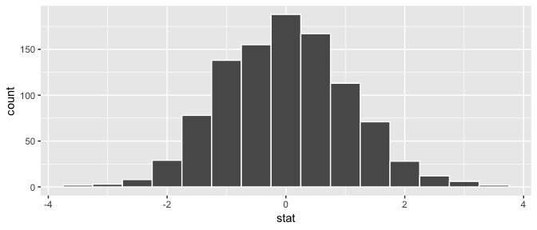

```r
prof_small %>%
  specify(age ~ sex) %>% # alt: response = age, explanatory = sex
  hypothesize(null = "independence") %>%
  generate(reps = 1000) %>%
  calculate(stat = "t", order = c("m", "f")) %>%
  visualize()
```

Theoretical distribution

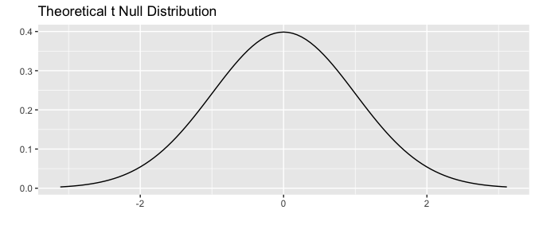

```r
prof_small %>%
  specify(age ~ sex) %>% # alt: response = age, explanatory = sex
  hypothesize(null = "independence") %>%
  # generate() is not needed since we are not doing simulation-based
  calculate(stat = "t", order = c("f", "m")) %>%
  visualize(method = "theoretical")
```

Overlay appropriate $t$ distribution on top of permuted t-statistics

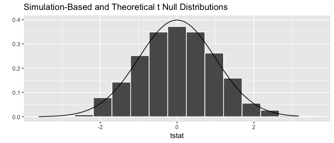

```r
prof_small %>%
  specify(age ~ sex) %>% # alt: response = age, explanatory = sex
  hypothesize(null = "independence") %>%
  generate(reps = 1000) %>%
  calculate(stat = "t", order = c("m", "f")) %>%
  visualize(method = "both")
```

### One numerical, one categorical (>2 levels) - ANOVA

Simulation-based approach to F-statistic

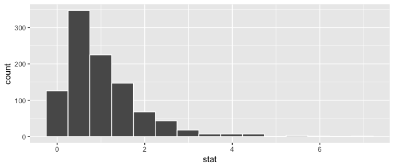

```r
prof_small %>%
  specify(age ~ status) %>% # alt: response = age, explanatory = status
  hypothesize(null = "independence") %>%
  generate(reps = 1000) %>%
  calculate(stat = "F") %>%
  visualize()
```

Theoretical distribution

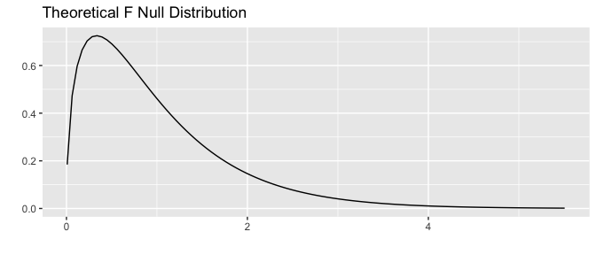

```r
prof_small %>%
  specify(age ~ status) %>% # alt: response = age, explanatory = status
  hypothesize(null = "independence") %>%
  # generate() is not needed since we are not doing simulation-based
  calculate(stat = "F") %>%
  visualize(method = "theoretical")
```

Overlay appropriate $F$ distribution on top of permuted F-statistics

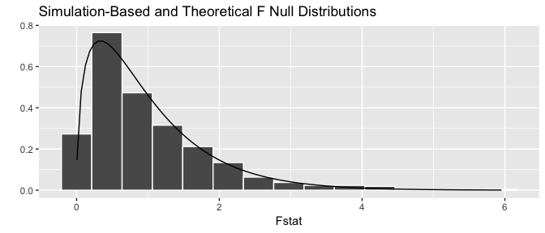

```r
prof_small %>%
  specify(age ~ status) %>% # alt: response = age, explanatory = status
  hypothesize(null = "independence") %>%
  generate(reps = 1000) %>%
  calculate(stat = "F") %>%
  visualize(method = "both")
```

## One categorical (2 level) variable

Simulation-based approach to z-statistic

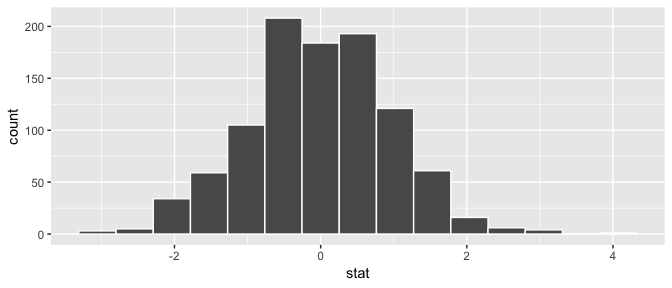

```r
prof_small %>%
  specify(response = sex, success = "m") %>%
  hypothesize(null = "point", p = c("m" = .65, "f" = .35)) %>%
  generate(reps = 1000) %>%
  calculate(stat = "z") %>%
  visualize()
```

Theoretical distribution

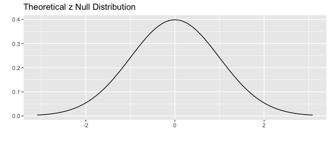

```r
prof_small %>%
  specify(response = sex, success = "m") %>%
  hypothesize(null = "point", p = c("m" = .65, "f" = .35)) %>%
  # generate() is not needed since we are not doing simulation-based
  calculate(stat = "z") %>%
  visualize(method = "theoretical")
```

Overlay standard normal distribution on top of permuted z-statistics

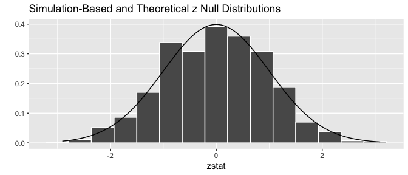

```r
prof_small %>%
  specify(response = sex, success = "m") %>%
  hypothesize(null = "point", p = c("m" = .65, "f" = .35)) %>%
  generate(reps = 1000) %>%
  calculate(stat = "z") %>%
  visualize(method = "both")
```

## Two categorical (2 level) variables

Simulation-based approach to z-statistic

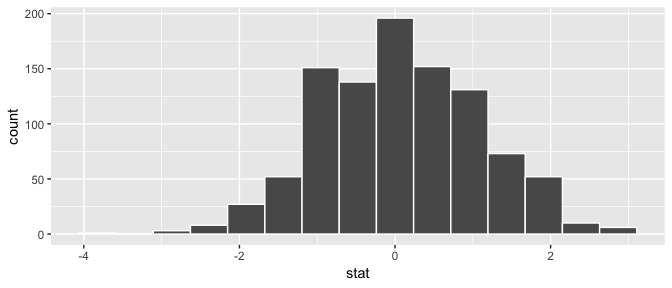

```r
prof_small %>%
  specify(sex ~ city, success = "m") %>%
  hypothesize(null = "independence") %>%
  generate(reps = 1000) %>%
  calculate(stat = "z", order = c("san fran", "not san fran")) %>%
  visualize()
```

Theoretical distribution

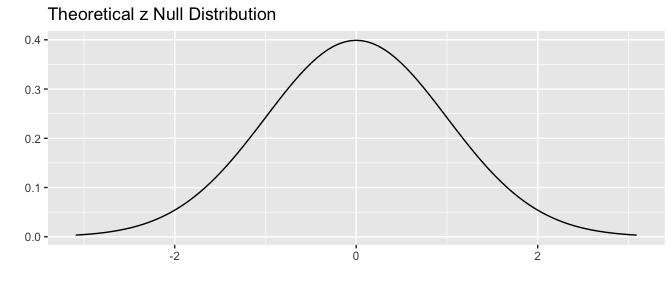

```r
prof_small %>%
  specify(sex ~ city, success = "m") %>%
  hypothesize(null = "independence") %>%
  # generate() is not needed since we are not doing simulation-based
  calculate(stat = "z", order = c("san fran", "not san fran")) %>%
  visualize(method = "theoretical")
```

Overlay standard normal distribution on top of permuted z-statistics

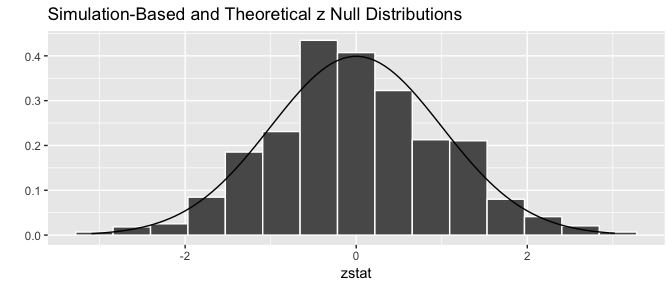

```r
prof_small %>%
  specify(sex ~ city, success = "m") %>%
  hypothesize(null = "independence") %>%
  generate(reps = 1000) %>%
  calculate(stat = "z", order = c("san fran", "not san fran")) %>%
  visualize(method = "both")
```

## Two categorical (>2 level) variables

Simulation-based approach to $\chi^2$-statistic

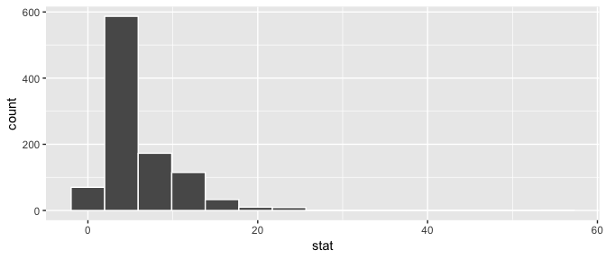

```r
prof_small %>%
  specify(drugs ~ status) %>% # alt: response = drugs, explanatory = status
  hypothesize(null = "independence") %>%
  generate(reps = 1000) %>%
  calculate(stat = "Chisq") %>%
  visualize()
```

Theoretical distribution

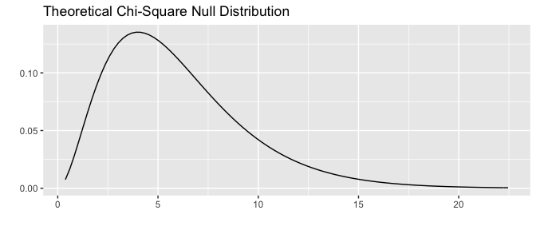

```r
prof_small %>%
  specify(drugs ~ status) %>% # alt: response = drugs, explanatory = status
  hypothesize(null = "independence") %>%
  # generate() is not needed since we are not doing simulation-based
  calculate(stat = "Chisq") %>%
  visualize(method = "theoretical")
```

Overlay chi-square distribution on top of permuted statistics

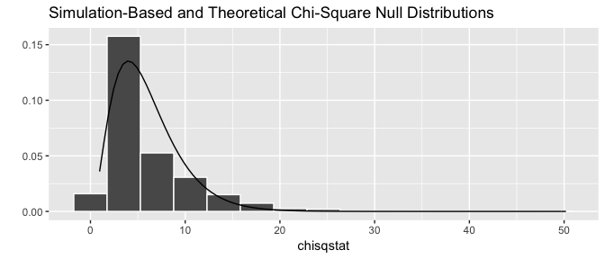

```r
prof_small %>%
  specify(drugs ~ status) %>% # alt: response = drugs, explanatory = status
  hypothesize(null = "independence") %>%
  generate(reps = 1000) %>%
  calculate(stat = "Chisq") %>%
  visualize(method = "both")
```

## One categorical (>2 level) - GoF

Simulation-based approach to $\chi^2$-statistic

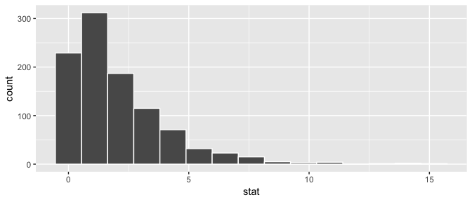

```r
prof_small %>%
  specify(drugs ~ NULL) %>% # alt: response = drugs
  hypothesize(null = "point",
              p = c("never" = .7, "often" = .05, "sometimes" = .25)) %>%
  generate(reps = 1000) %>%
  calculate(stat = "Chisq") %>%
  visualize()
```

Theoretical distribution

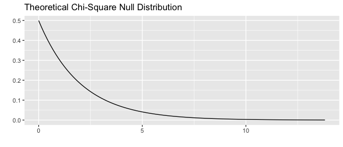

```r
prof_small %>%
  specify(drugs ~ NULL) %>% # alt: response = drugs
  hypothesize(null = "point",
              p = c("never" = .7, "often" = .05, "sometimes" = .25)) %>%
  # generate() is not needed since we are not doing simulation-based
  calculate(stat = "Chisq") %>%
  visualize(method = "theoretical")
```

Overlay standard chi-square distribution on top of permuted statistics

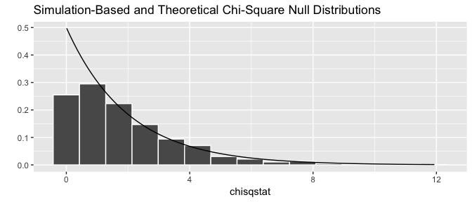

```r
prof_small %>%
  specify(drugs ~ NULL) %>% # alt: response = drugs
  hypothesize(null = "point",
              p = c("never" = .7, "often" = .05, "sometimes" = .25)) %>%
  generate(reps = 1000) %>%
  calculate(stat = "Chisq") %>%
  visualize(method = "both")
```

## Two numerical vars - t

Not currently implemented since $t$ could refer to standardized slope or standardized correlation

# Determining whether or not to implement

Note that all code from here throughout the rest of this vignette is to think about but is not currently implemented

## One numerical variable (mean)

Simulation-based approach to $t$-statistic (Not implemented)

```r
prof_small %>%
  specify(response = age) %>% # alt: age ~ NULL (or age ~ 1)
  hypothesize(null = "point", mu = 50) %>%
  generate(reps = 1000) %>%
  calculate(stat = "t") %>%
  visualize()
```

Theoretical distribution (Implemented)

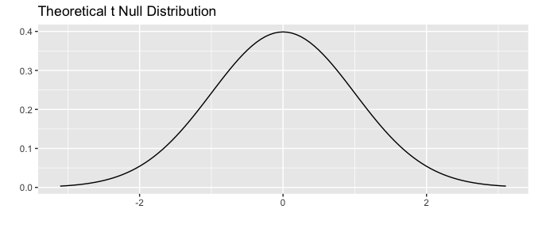

```r
prof_small %>%
  specify(response = age) %>% # alt: age ~ NULL (or age ~ 1)
  hypothesize(null = "point", mu = 50) %>%
  # generate() is not needed since we are not doing simulation-based
  calculate(stat = "t") %>%
  visualize(method = "theoretical")
```

Overlay appropriate $t$ distribution on top of permuted t-statistics (Not implemented)

```r
prof_small %>%
  specify(response = age) %>% # alt: age ~ NULL (or age ~ 1)
  hypothesize(null = "point", mu = 50) %>%
  generate(reps = 1000) %>%
  calculate(stat = "t") %>%
  visualize(method = "both")
```

## Confidence intervals

### To Do (one mean $t$ stat)

### To Do (Also overlay appropriate t distn)

One numerical (one mean)

```r
prof_small %>%
  specify(response = age) %>%
  generate(reps = 1000, type = "bootstrap") %>%
  calculate(stat = "mean") %>%
  visualize()
```

### To Do (one prop $z$ stat)

### To Do (Also overlay std normal distn)

One categorical (one proportion)

```r
prof_small %>%
  specify(response = sex) %>%
  generate(reps = 1000, type = "bootstrap") %>%
  calculate(stat = "prop", success = "f") %>%
  visualize()
```

### To Do (Also overlay appropriate t distn)

### To Do (Shift t stats to be centered at 0 for bootstrapping)

One numerical variable one categorical (2 levels) (diff in means)

```r
prof_small %>%
  specify(age ~ sex) %>%
  generate(reps = 1000, type = "bootstrap") %>%
  calculate(stat = "t") %>%
  visualize()
```

### To Do (two prop $z$ stat)

### To Do (Also overlay appropriate std normal distn)

### To Do (Shift z stats to be centered at 0 for bootstrapping)

Two categorical variables (diff in proportions)

```r
prof_small %>%
  specify(sex ~ city) %>%
  generate(reps = 1000, type = "bootstrap") %>%
  calculate(stat = "diff in props") %>%
  visualize()
```

### To Do (Also overlay appropriate t distn)

### To Do (Shift t stats to be centered at 0 for bootstrapping)

Two numerical vars - SLR

```r
prof_small %>%
  specify(age ~ height) %>%
  generate(reps = 1000, type = "bootstrap") %>%
  calculate(stat = "slope") %>%
  visualize()
```